# Problem Set 8

## **EECS225B Problem Set 8**

### **Problem 2: Two-dimensional Discrete Wavelet Transforms**

A. The J-Scale 2D DWT is implemented below:

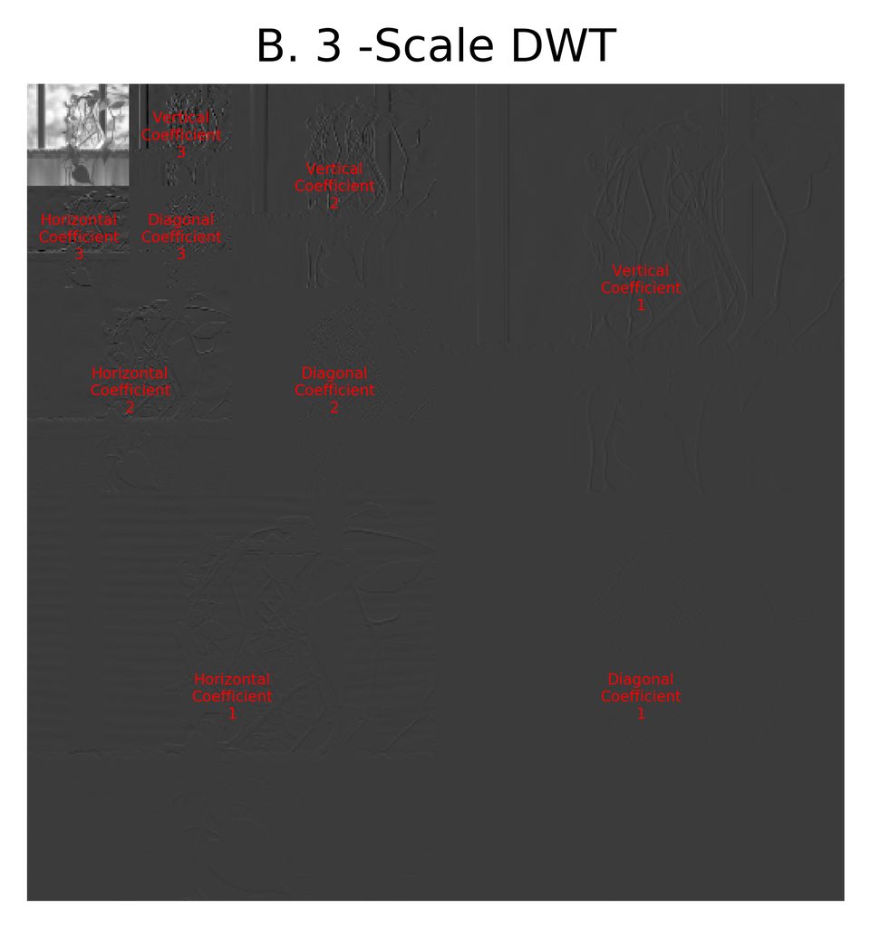

C. The Inverse J-Scale 2D DWT is implemented below.

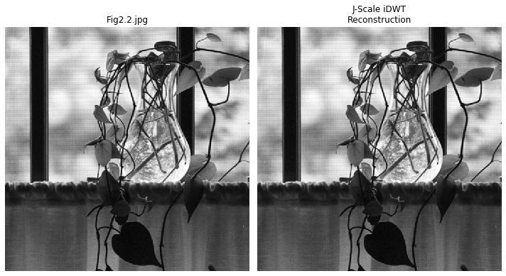

D. The scaled 2D DWT is implemented below. Here, I scaled the detail coefficients between 0 and 1 after each iteration of the transform. At the end, I scale the compressed image similarly between 0 and 1. The final image is scaled to 0-255.

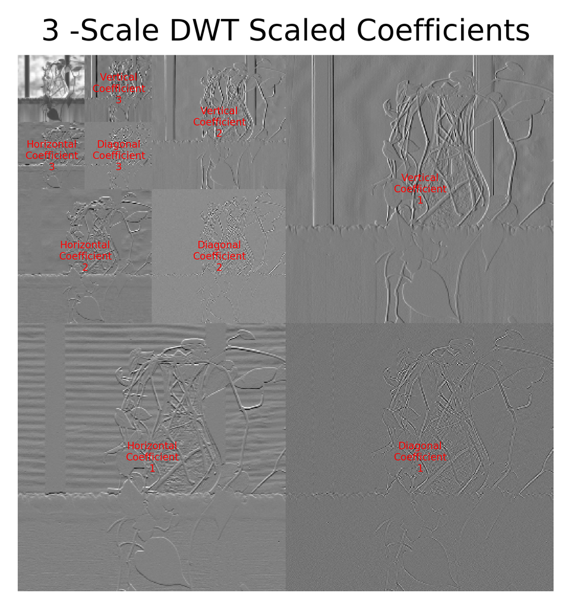

### **Problem 3: Wavelet Transform Modifications**

A.

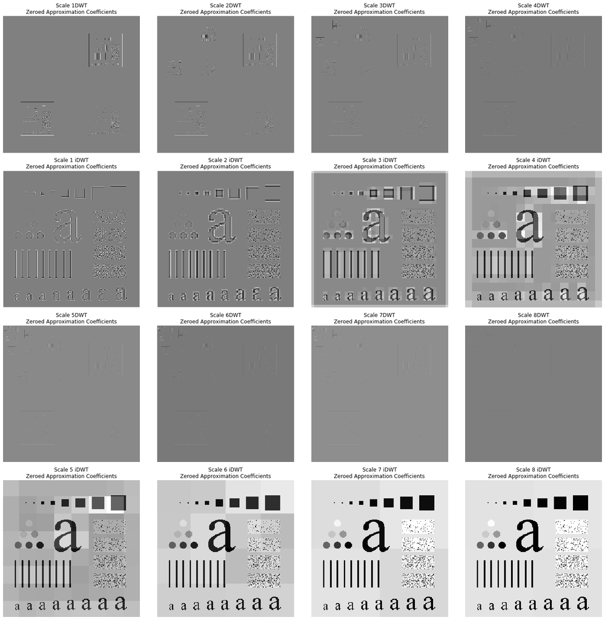

We can see as the scale increases, the quality of the reconstruction increases. This is because with more iterations of the jrange, the more low frequency components are extracted from approximation coefficient and relocated to the detail coefficients.  
B.

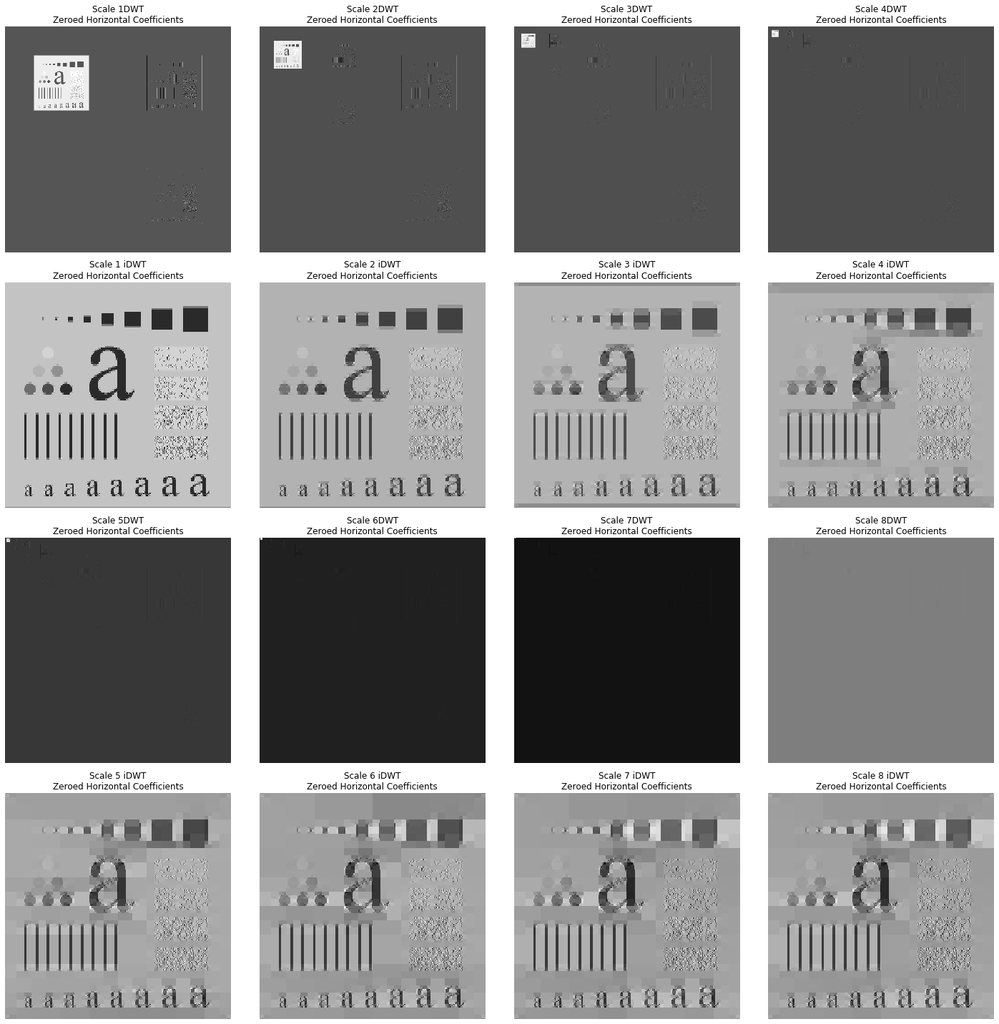

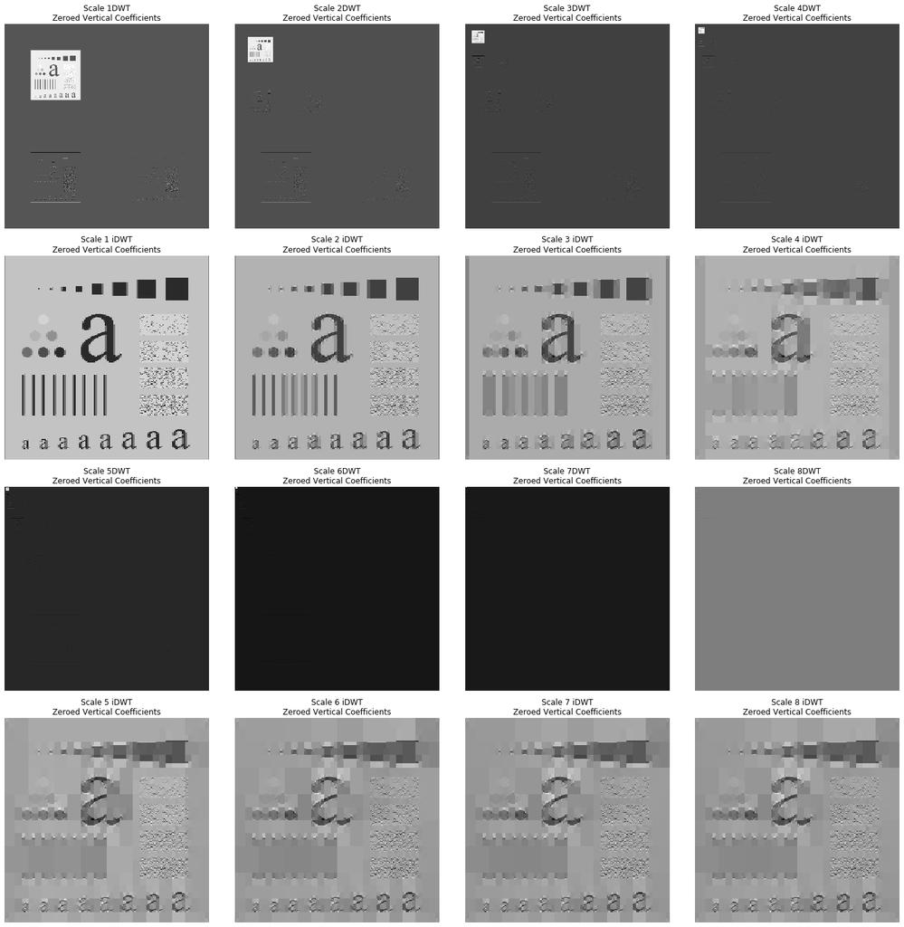

The results here are similar to B, except that now the vertical components are now obscured.  
D.

[figure not shown]

Now that both the horizontal and vertical components have been removed, only the faint diagonal frequencies in the image are preserved.

### **Problem 4: Wavelet Coding**

The RMSE and SNR function for Problem Set #7 are used here.

The reference images used to calculate RMSE and SNR are obtained by downsampling via skimage.transform.resize. A gaussian filter is for antialiasing during downsampling.

[figure not shown]